# RNA-seq analysis pipeline

**Look at the objects**

```r
names( de.tgw )
```

```
## [1] "table"      "comparison" "genes"
```

```r
de.tgw$comparison # which groups have been compared
```

```
## [1] "def"   "recov"
```

```r
head( de.tgw$table )
```

```
##                         logFC    logCPM     PValue
## GSONMT00000001001 -0.12633449 0.4516277 0.75870340
## GSONMT00000003001  0.05600619 2.5387704 0.84674804
## GSONMT00000006001 -0.53738020 0.4353018 0.13669114
## GSONMT00000012001 -0.39373765 0.4938172 0.36103691
## GSONMT00000013001 -0.07644114 0.9116025 0.82483569
## GSONMT00000014001 -1.32111837 0.1833772 0.00285925
```

```r
head( cds$counts )
```

```
##                   def_R1 def_R2 def_R3 recov_R1 recov_R2 recov_R3
## GSONMT00000001001     50     41     50       52       38       26
## GSONMT00000003001    220    177    182      160      282      124
## GSONMT00000006001     61     40     58       39       40       20
## GSONMT00000012001     64     34     63       50       21       34
## GSONMT00000013001     69     67     54       54       67       46
## GSONMT00000014001     52     34     75       19       10       26
```

**Top tags for tagwise analysis**

```
## Comparison of groups:  recov-def
##                   logFC  logCPM   PValue      FDR
## GSONMT00047257001 -6.02  2.2754 2.33e-46 5.45e-42
## GSONMT00010443001 -6.31  2.6455 1.07e-41 1.25e-37
## GSONMT00068292001 -4.52  2.8913 2.10e-41 1.64e-37
## GSONMT00047275001 -5.20  3.0912 1.68e-36 9.86e-33
## GSONMT00052411001 -3.72  2.2464 5.26e-33 2.47e-29
## GSONMT00052968001 -5.22  1.8901 3.76e-29 1.47e-25
## GSONMT00003792001 -4.78  1.1887 1.22e-28 4.09e-25
## GSONMT00072318001 -3.44  2.0265 1.38e-26 4.04e-23
## GSONMT00071336001 -9.03  0.0904 1.67e-25 4.34e-22
## GSONMT00071082001 -4.89  1.0730 1.35e-24 3.17e-21
## GSONMT00005432001 -4.02  1.1312 3.25e-24 6.93e-21
## GSONMT00056136001 -3.20  1.8806 4.53e-24 8.85e-21
## GSONMT00079460001 -4.87  1.1755 9.76e-23 1.76e-19
## GSONMT00043612001 -6.30  0.1134 1.40e-22 2.34e-19
## GSONMT00053331001 -4.87  0.7637 1.64e-22 2.56e-19
## GSONMT00050133001 -8.67 -0.2519 2.47e-22 3.61e-19
## GSONMT00078625001 -3.79  2.8420 1.03e-21 1.42e-18
## GSONMT00021751001 -4.86  0.7796 1.55e-21 2.02e-18
## GSONMT00062097001 -6.68 -0.2889 6.58e-20 8.11e-17
## GSONMT00006698001 -4.62  0.9163 7.49e-20 8.77e-17
```

**Sort tagwise results by Fold-Change instead of p-value, and get all genes**

```r
resultsByFC.tgw <- topTags( de.tgw , n = nrow( de.tgw$table ) , sort.by = "logFC" )$table
head( resultsByFC.tgw )
```

```
##                   logFC  logCPM   PValue      FDR
## GSONMT00071336001 -9.03  0.0904 1.67e-25 4.34e-22
## GSONMT00050133001 -8.67 -0.2519 2.47e-22 3.61e-19
## GSONMT00062097001 -6.68 -0.2889 6.58e-20 8.11e-17
## GSONMT00077521001 -6.48 -0.4669 8.89e-19 9.46e-16
## GSONMT00010443001 -6.31  2.6455 1.07e-41 1.25e-37
## GSONMT00043612001 -6.30  0.1134 1.40e-22 2.34e-19
```

**Store full topTags results table**

```r
resultsTbl.cmn <- topTags( de.cmn , n = nrow( de.cmn$table ) )$table
resultsTbl.tgw <- topTags( de.tgw , n = nrow( de.tgw$table ) )$table
resultsTbl.poi <- topTags( de.poi , n = nrow( de.poi$table ) )$table
head( resultsTbl.tgw )
```

```
##                   logFC logCPM   PValue      FDR
## GSONMT00047257001 -6.02   2.28 2.33e-46 5.45e-42
## GSONMT00010443001 -6.31   2.65 1.07e-41 1.25e-37
## GSONMT00068292001 -4.52   2.89 2.10e-41 1.64e-37
## GSONMT00047275001 -5.20   3.09 1.68e-36 9.86e-33
## GSONMT00052411001 -3.72   2.25 5.26e-33 2.47e-29
## GSONMT00052968001 -5.22   1.89 3.76e-29 1.47e-25
```

**Names/IDs of DE genes**

```r
de.genes.cmn <- rownames( resultsTbl.cmn )[ resultsTbl.cmn$FDR <= 0.05 ]
de.genes.tgw <- rownames( resultsTbl.tgw )[ resultsTbl.tgw$FDR <= 0.05 ]
de.genes.poi <- rownames( resultsTbl.poi )[ resultsTbl.poi$FDR <= 0.05 ]
```

**Look how many genes in each group**

```r
length( de.genes.tgw )
```

```
## [1] 453
```

```r
summary( decideTestsDGE( de.tgw , p.value = 0.05 ) )
```

```
##    [,1]
## -1   328
## 0  22970
## 1    125
```

**Plot the results**

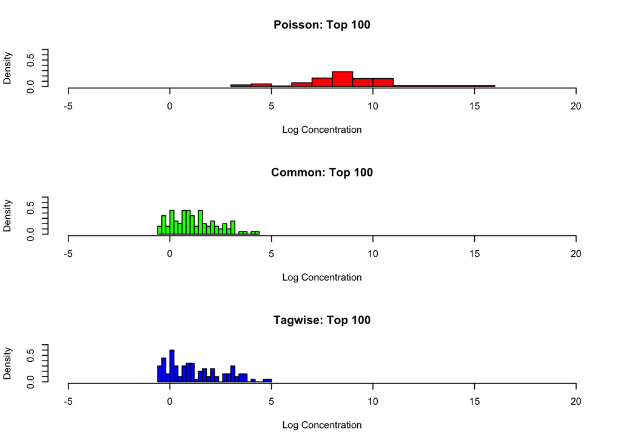

```r
par( mfrow=c(3 ,1) ) #makes 3 plots on same screen

hist(resultsTbl.poi[de.genes.poi[1:100],"logCPM"] , breaks=10 , xlab="Log Concentration" , col="red" , xlim=c(-5,20) , ylim=c(0,0.7) , freq=FALSE , main="Poisson: Top 100" )
hist(resultsTbl.cmn[de.genes.cmn[1:100],"logCPM"] , breaks=25 , xlab="Log Concentration" , col="green" , xlim=c(-5,20) , ylim=c(0,0.7) , freq=FALSE , main="Common: Top 100" )
hist( resultsTbl.tgw[de.genes.tgw[1:100],"logCPM"] , breaks=25 , xlab="Log Concentration" , col="blue" , xlim=c(-5,20) , ylim=c(0,0.7) , freq=FALSE , main="Tagwise: Top 100" )
```

```r
par( mfrow=c(1,1) )
```

**MA plot**

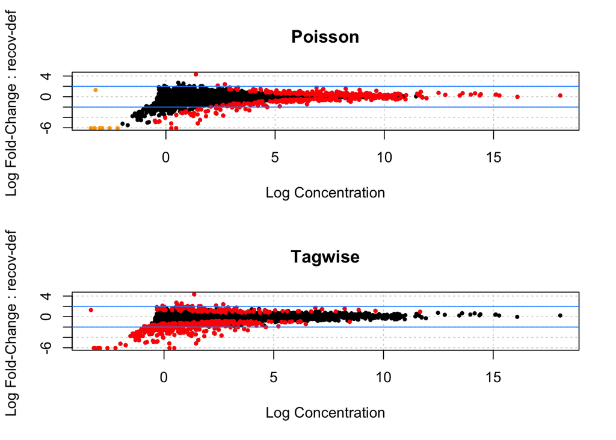

```r
par( mfrow = c(2,1) )
plotSmear( cds , de.tags=de.genes.poi[1:500] , main="Poisson" ,pair=c("def","recov") , cex=.5 , xlab="Log Concentration" , ylab="Log Fold-Change" )
abline( h=c(-2,2) , col="dodgerblue" )

plotSmear( cds , de.tags=de.genes.tgw[1:500] , main="Tagwise" , pair=c("def","recov") ,cex = .5 ,
           xlab="Log Concentration" , ylab="Log Fold-Change" )
abline( h=c(-2,2) , col="dodgerblue" )
```

```r
par( mfrow=c(1,1) )
```

**Resume files**

```r
#resume files
colnames( resultsTbl.cmn ) <- c( "logFC" , "logCPM" , "pValue.cmn" , "FDR.cmn" )
colnames( resultsTbl.tgw ) <- c( "logFC" , "logCPM" , "pValue.tgw" , "FDR.tgw" )
write.csv(resultsTbl.tgw, file="tagwise_edgeR_Results.csv", row.names = TRUE)
write.csv(resultsTbl.cmn, file="common_edgeR_Results.csv", row.names = TRUE)
```

# 8. Functionnal DE gene annotation

## Preparing and uncompress Uniprot database

**Download Uniprot-sprot.fa database**

```
> wget ftp://ftp.uniprot.org/pub/databases/uniprot/current_release/knowledgebase/complete/uniprot_sprot.fasta.gz
> gunzip uniprot_sprot.fasta.gz
```

**Indexing Uniprot database for Blastx**

```
> makeblastdb -in uniprot_sprot.fasta -input_type 'fasta' -dbtype 'prot'
```

## Prepare .fasta file of DE genes

**Create a list of DE gene names**

```
> awk -F "," '{print $1}' def_recov_deseq2_tophat.csv > list_def_recov.txt
```

**Download and uncompress mRNA.fa file for rainbow trout**

```
> wget http://www.genoscope.cns.fr/trout/data/Oncorhynchus_mykiss_mRNA.fa.gz
> gunzip Oncorhynchus_mykiss_mRNA.fa.gz
```

**Create .fasta file for DE genes using Python script ‘get_fasta_alignedContig.py’**

```
> cat get_fasta_alignedContig.py

#!/usr/bin/python
# encoding: utf-8

"""
usage:
keep_contig.py list.txt Contigs.fna
"""

class Printer:
  def __init__ (self, contigName):
        self.printing = False
        self.contigList = []
        for id in open(contigName):
            self.contigList.append(id.strip())

    def parseLine(self, line):
        if '>' in line:
            tokens = line.strip().split()
            if tokens[0][1:] in self.contigList:
                self.printing = True
                print line.strip()
            else:
                self.printing = False
        else:
            if self.printing == True:
                print line.strip()

import sys

if __name__ == "__main__":
    if len(sys.argv) != 3:
        print __doc__
        sys.exit(1)

    contigName=sys.argv[1]
    printer = Printer(contigName)
    filename=sys.argv[2]
    for line in open(filename):
        printer.parseLine(line)
```

*Note: This is a Python script, please make sure indentations are correct*

**Run get_fasta_alignedContig.py**

```
> ./get_fasta_alignedContig.py list_def_recov.txt Oncorhynchus_mykiss_mRNA.fa > def_recov.fasta
```

*Note: use chmod +x script.sh before try running the script

## Blastx against uniprot

```
> cat blast_template.sh

#!/bin/bash
#PBS -A _user_colosse_ID_
#PBS -N blastx
#PBS -o blastx.out
#PBS -e blastx.err
#PBS -l walltime=00:40:00
#PBS -l nodes=1:ppn=8
#PBS -r n

cat def_recov.fasta | parallel -j 8 -k --block 10k --recstart '>' --pipe blastx -db /home/_user_name_/uniprot_sprot.fasta  -query - -outfmt 6 -max_target_seqs 1 -evalue 1e-6 > blastx_def_norm.txt
```

*Note: the allocation time needs to be adapted to the query size*

Blastx output file should look like:

```
> head -n 5 blastx_def_recov.txt

GSONMT00078625001  sp|P17691|NEUM_CARAU 90.74   54  5   0   190 351 1   54  8e-25    107
GSONMT00056687001   sp|Q9H2B2|SYT4_HUMAN    55.00   300 103 6   109 999 13  283 4e-94    293
GSONMT00056687001   sp|Q9H2B2|SYT4_HUMAN    37.82   119 66  4   607 957 287 399 1e-08   60.1
GSONMT00059422001   sp|Q6IR52|PBX2_XENLA    81.82   99  14  1   340 624 237 335 4e-44    167
GSONMT00044618001   sp|Q9R0B6|LAMC3_MOUSE   57.64   144 61  0   4   435 732 875 2e-48    176
```

## Prepare Uniprot_id for Gominer

**Extract uniq Uniprot_ID for a Gene**

```
> awk '{print $1,$2}' blastx_def_norm.txt|awk '{ if (!($1 in a)) a[$1] = $2; else if (a[$1] < $2) a[$1] = $2 } END { for (key in a) print key, a[key] }'|awk -F "|" '{print $2}' > GO_def_norm.txt
```

The GO_list file should look like:

```
> head -n 5 GO_def_norm.txt

Q6P9J5
Q95KE5
P02457
Q1L8Y6
Q9NVD7
```

**Use GO_list in GOminer interface**

```
http://discover.nci.nih.gov/gominer/GoCommandWebInterface.jsp
```

For more information, please contact: jeremy.le.luyer@gmail.com